# Štatistické metódy vyhodnocovania experimentov

7. Testy dobrej zhody

Tomáš Bacigál

6.4.2021

```r
`%>%` <- magrittr::`%>%`  # pipe operator
```

# 4 Testovanie štatistických hypotéz

## 4.1 Testy dobrej zhody

### 4.1.1 Jednovýberové

Jednovýberové testy o parametroch normálneho rozdelenia ako sú t-test či F-test, ale aj mnohé ďalšie, ktoré zaraďujeme do triedy tzv. parametrických testov, predpokladajú, že náhodný výber pochádza z *normálne rozdeleného* základného súboru. Na overenie, či náhodný výber pochádza z nejakého hypotetického rozdelenia, slúžia jednovýberové testy dobrej zhody. Najčastejšie používané testy dobrej zhody (špecificky iba) s normálnym rozdelením sú Shapiro-Wilk, Lillifers a Jarque-Bera. Všeobecnejšie testy dobrej zhody sú najmä Pearsonov $\chi^2$, Kolmogorov-Smirnov, Anderson-Darling či test s použitím Cramér-von Mises kritéria.  
Balík *nortest* uľahčuje testovanie normality pomocou všeobecných testov.

**Úloha:**

Rôznymi testami otestujte, či výber pochádza z normálneho rozdelenia.

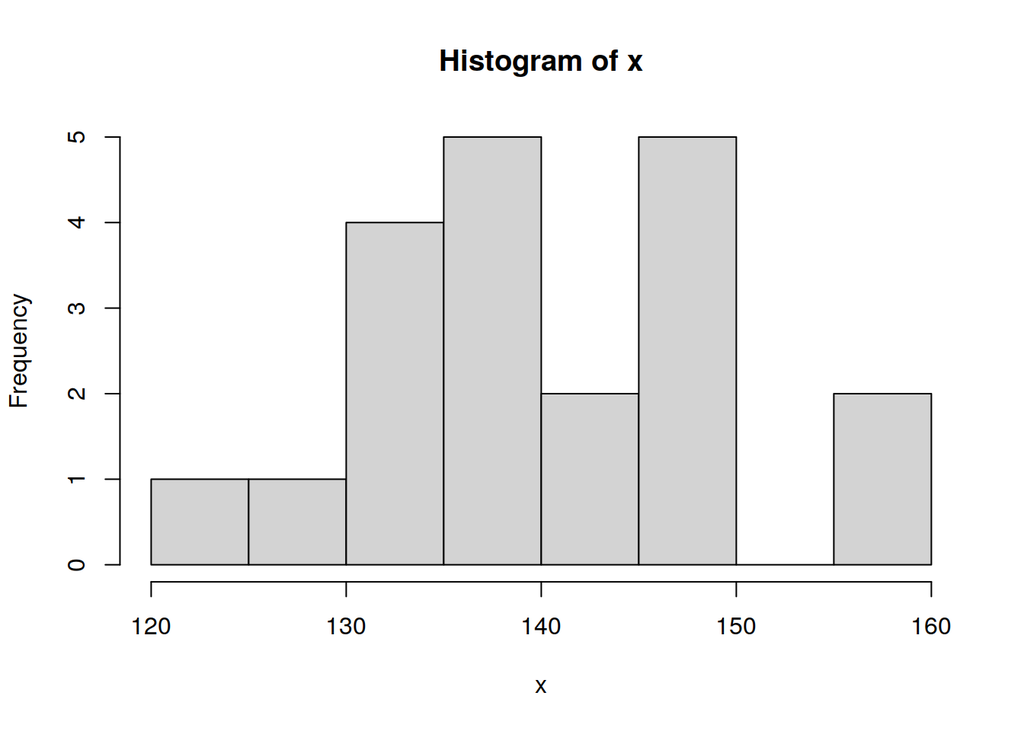

```r
x <- c(146,130,138,135,159,131,150,140,139,148,156,123,131,150,137,139,144,149,142,134) # paste(round(rnorm(20, 140, 7)), collapse=",")
hist(x)
```

```r
xmean <- mean(x)
xsd <- sd(x)
n <- length(x)
c(xmean = xmean, xsd = xsd, n = n, range = range(x)) %>% round(2)
```

```
##  xmean    xsd      n range1 range2
## 141.05   9.24  20.00 123.00 159.00
```

#### 4.1.1.1 $\chi^2$ (chi kvadrát) test dobrej zhody

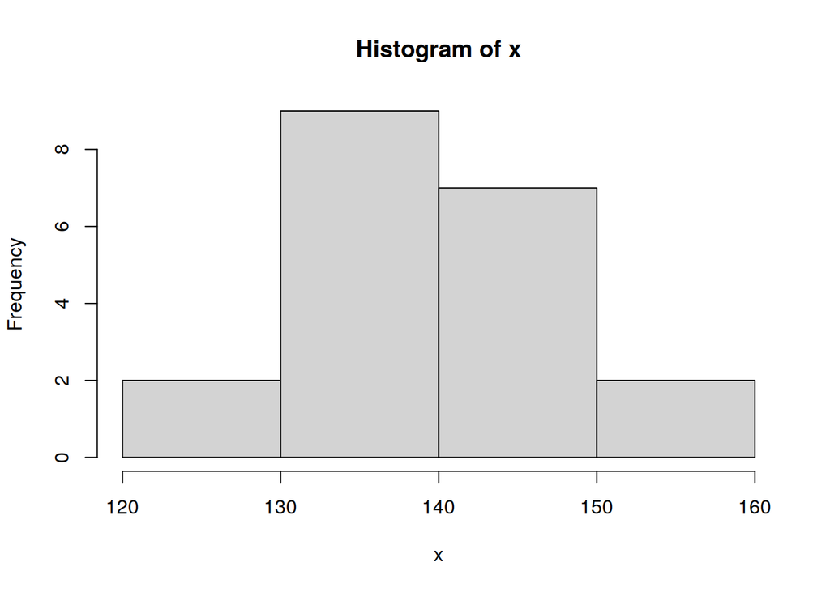

```
## $breaks
## [1] 120 130 140 150 160
##
## $counts
## [1] 2 9 7 2
##
## $density
## [1] 0.010 0.045 0.035 0.010
##
## $mids
## [1] 125 135 145 155
##
## $xname
## [1] "x"
##
## $equidist
## [1] TRUE
##
## attr(,"class")
## [1] "histogram"
```

```r
his <- hist(x, breaks=c(120,130,140,150,160)); his
```

```r
k <- length(his$breaks)-1; k
```

```
## [1] 4
```

```r
hranice <- his$breaks
hranice[1] <- -Inf; hranice[k+1] <- Inf
pravdep <- diff( pnorm(hranice, mean=xmean, sd=xsd) ); pravdep
```

```
## [1] 0.1159260 0.3388478 0.3787997 0.1664265
```

```r
pocetnost <- list(
  skutocna = his$counts,
  teoreticka = pravdep*n
); pocetnost
```

```
## $skutocna
## [1] 2 9 7 2
##
## $teoreticka
## [1] 2.318520 6.776955 7.575994 3.328530
```

```r
TS <- sum( (pocetnost$skutocna - pocetnost$teoreticka)^2 / pocetnost$teoreticka )  # test. statistika
stupne <- length(pravdep) - 1 - 2  # stupne voľnosti
c(test_statistika = TS,
  df = stupne,
  krit_hodnota = qchisq(0.95, df = stupne),
  p_hodnota = 1 - pchisq(TS, df = stupne)
) %>% round(3)
```

```
## test_statistika              df    krit_hodnota       p_hodnota
##           1.347           1.000           3.841           0.246
```

vstavaný test

```r
chisq.test(pocetnost$skutocna, p = pravdep) # nortest::pearson.test(x, n.classes = k)
```

```
##
##  Chi-squared test for given probabilities
##
## data:  pocetnost$skutocna
## X-squared = 1.347, df = 3, p-value = 0.718
```

#### 4.1.1.2 Kolmogorov-Smirnov test

H0: X pochádza z N(xmean,xsd)  
Kolmogorov-Smirnov test porovnáva empirickú distribučnú funkciu s hypotetickou, kritériom (testovacou štatistikou) je maximálny rozdiel medzi ich hodnotami.

```r
xsort <- sort(x); xsort
```

```
##  [1] 123 130 131 131 134 135 137 138 139 139 140 142 144 146 148 149 150 150 156
## [20] 159
```

```r
Fn <- rank(xsort, ties.method="max")/n; Fn
```

```
##  [1] 0.05 0.10 0.20 0.20 0.25 0.30 0.35 0.40 0.50 0.50 0.55 0.60 0.65 0.70 0.75
## [16] 0.80 0.90 0.90 0.95 1.00
```

```r
Ft <- pnorm(xsort, mean=xmean, sd=xsd); Ft
```

```
##  [1] 0.02541001 0.11592602 0.13842950 0.13842950 0.22278995 0.25636091
##  [7] 0.33061814 0.37069707 0.41223150 0.41223150 0.45477379 0.54093489
## [13] 0.62520794 0.70387774 0.77396989 0.80515619 0.83357350 0.83357350
## [19] 0.94712329 0.97394213
```

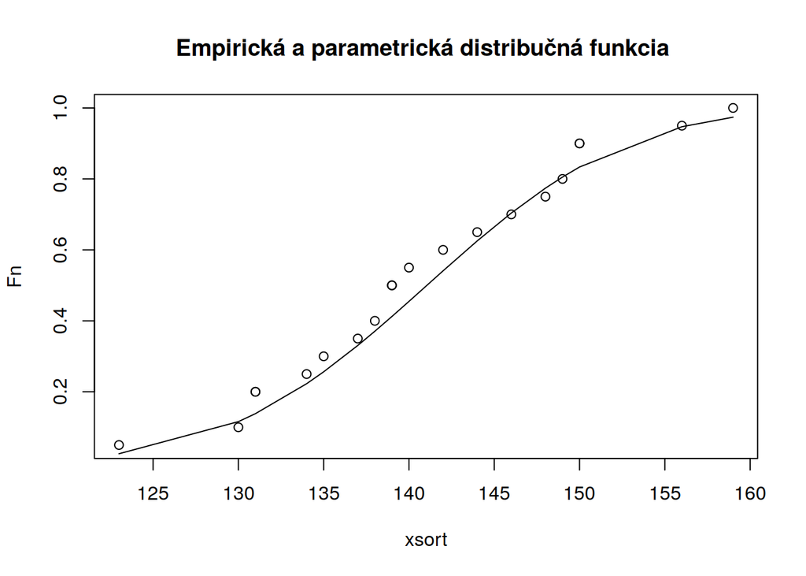

```r
plot(xsort, Fn, main="Empirická a parametrická distribučná funkcia ")
lines(xsort, Ft)     # EnvStats::cdfCompare(x)
```

```r
TS <- max(abs(Fn-Ft))
c(test.stat = TS,
  asympt.krit.val = sqrt(log(2/0.05) / (2*n))
)
```

```
##       test.stat asympt.krit.val
##      0.09522621      0.30368073
```

Kritická hodnota = 0.294 (z tabuliek pre n=20, alfa=0.05), čiže H0 nezamietame.

Alternatívne vstavanými funkciami

```r
ks.test((x - xmean) / xsd, pnorm)
```

```
##
##  One-sample Kolmogorov-Smirnov test
##
## data:  (x - xmean)/xsd
## D = 0.095226, p-value = 0.9935
## alternative hypothesis: two-sided
```

```r
# alebo  ks.test(x, function(y) pnorm(y, mean=xmean, sd=xsd))
nortest::lillie.test(x)  # DescTools::LillieTest(x),  špeciálne pre norm.rozd.
```

```
##
##  Lilliefors (Kolmogorov-Smirnov) normality test
##
## data:  x
## D = 0.095226, p-value = 0.9055
```

Lillieforsov test normality je v tomto prípade vhodnejší, pretože parametre normálneho rozdelenia nepoznáme a museli sme ich odhadnúť. Preto sa rozdelenie testovacej štatistiky iné ako pri KS teste (a tak aj p-hodnota).

#### 4.1.1.3 Anderson-Darling test

H0: X pochadza z N(xmean,xsd)

```r
goftest::ad.test(x, null = pnorm, mean = mean(x), sd = sd(x), estimated = F)
```

```
##
##  Anderson-Darling test of goodness-of-fit
##  Null hypothesis: Normal distribution
##  with parameters mean = 141.05, sd = 9.24220866744695
##  Parameters assumed to be fixed
##
## data:  x
## An = 0.16295, p-value = 0.9976
```

```r
# špeciálne pre norm.rozd.   nortest::ad.test(x)
```

#### 4.1.1.4 Cramér-von Mises test

H0: X pochadza z N(xmean, xsd)

```r
TS <- 1/(12*n) + sum( ((2*(1:n)-1)/(2*n) - Ft)^2 )
c(test.stat = TS,
  crit.val = goftest::qCvM(.95, n=20),
  p.val = 1 - goftest::pCvM(TS, n=20)
) %>% round(4)
```

```
## test.stat  crit.val     p.val
##    0.0244    0.4579    0.9924
```

H0 nezamietame  
vstavaný test:

```r
goftest::cvm.test(x, null = pnorm, mean = mean(x), sd = sd(x))
```

```
##
##  Cramer-von Mises test of goodness-of-fit
##  Null hypothesis: Normal distribution
##  with parameters mean = 141.05, sd = 9.24220866744695
##  Parameters assumed to be fixed
##
## data:  x
## omega2 = 0.024379, p-value = 0.9924
```

#### 4.1.1.5 Jarque-Bera test normality

To je test pomocou šikmosti (skewness) a špicatosti (kurtosis).

H0: X pochádza z N(xmean,xsd)

```r
SK <- (sum((x-xmean)^3)/n) / (sum((x-xmean)^2)/n)^(3/2)
KU <- (sum((x-xmean)^4)/n) / (sum((x-xmean)^2)/n)^2
c(šikmosť = SK, špicatosť = KU)
```

```
##   šikmosť špicatosť
## 0.1094099 2.4242276
```

```r
TS <- n*(SK^2/6 + (KU-3)^2/24)
c(test.stat = TS,
  crit.val = qchisq(0.95, df = 2),
  p.value = 1 - pchisq(TS, df = 2)
)
```

```
## test.stat  crit.val   p.value
## 0.3161632 5.9914645 0.8537801
```

Čiže H0 nezamietame.

```r
DescTools::JarqueBeraTest(x, robust = F)
```

```
##
##  Jarque Bera Test
##
## data:  x
## X-squared = 0.31616, df = 2, p-value = 0.8538
```

#### 4.1.1.6 Shapiro-Wilk test normality

H0: X pochádza z normálneho rozdelenia

```r
shapiro.test(x)
```

```
##
##  Shapiro-Wilk normality test
##
## data:  x
## W = 0.98438, p-value = 0.9776
```

### 4.1.2 Dvojvýberové

**Príklad** (Markechová 2011b, Príklad 9.19, str. 353)

Bolo vybraných 13 polí rovnakej kvality. Na 8 z nich sa skúšal nový spôsob hnojenia, na zvyšných 5 bol použitý tradičný spôsob hnojenia. Výnosy pšenice v tonách na hektár boli pri novom spôsobe hnojenia 5,7, 5,5, 4,3, 5,9, 5,2, 5,6, 5,8, 5,1 a pri tradičnom spôsobe hnojenia 5,0, 4,5, 4,2, 5,4, 4,4. Treba zistiť, či nový spôsob hnojenia má vplyv úrodu pšenice.

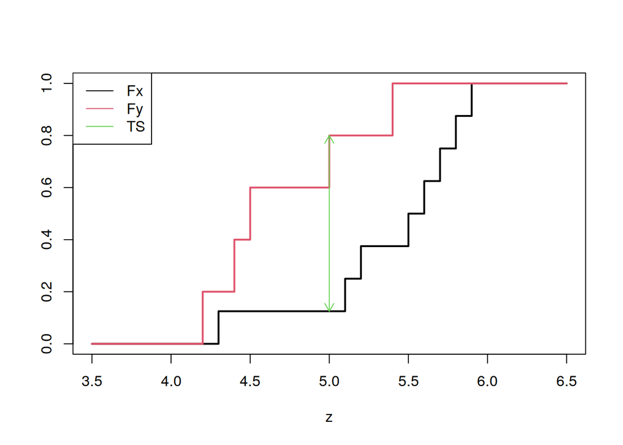

```r
x <- c(5.7, 5.5, 4.3, 5.9, 5.2, 5.6, 5.8, 5.1) %>% sort()
y <- c(5.0, 4.5, 4.2, 5.4, 4.4) %>% sort()
Fx <- ecdf(x)
Fy <- ecdf(y)
z <- seq(3.5, 6.5, 0.1)
plot(z, Fx(z), type = "s", lwd = 2, ylab = NA)
lines(z, Fy(z), type = "s", col = 2, lwd = 2)
arrows(x0 = 5.0, y0 = Fx(5.0), y1 = Fy(5.0), code = 3, length = 0.1, col = 3)
legend("topleft", legend = c("Fx", "Fy", "TS"), col = 1:3, lty = 1)
```

Na hladine významnosti 5% hypotézu H0 (Fx = Fy) NEzamietame v prospech hypotézy H1 (Fx < Fy, výber x je stochasticky väčší než y).

```r
c(test.stat = c(x,y) %>% {Fy(.) - Fx(.)} %>% max(),
  crit.val = 30/40,  # z tabuliek
  asymp.crit.val = list(x,y) %>% sapply(length) %>% {-log(0.05)/2 * sqrt(sum(.)/prod(.))}
)
```

```
##      test.stat       crit.val asymp.crit.val
##      0.6750000      0.7500000      0.8539151
```

vstavaným testom

```r
ks.test(x, y, alternative = "less") %>% str()
```

```
## List of 5
##  $ statistic  : Named num 0.675
##   ..- attr(*, "names")= chr "D^-"
##  $ p.value    : num 0.0606
##  $ alternative: chr "the CDF of x lies below that of y"
##  $ method     : chr "Two-sample Kolmogorov-Smirnov test"
##  $ data.name  : chr "x and y"
##  - attr(*, "class")= chr "htest"
```

Ak ide iba o porovnanie mier polohy, KS test má menšiu silu ako špecializované testy.

### 4.1.3 Odhad parametrov rozdelenia a test dobrej zhody

Niekedy parametre hypotetického rozdelenia poznáme, inokedy ich treba odhadnúť. Pri normálnom rozdelení je to pomerne jednoduché, pretože parametre sú zároveň aj momentami (stredná hodnota počiatočným a rozptyl druhým centrálnym momentom), ktoré sa dajú priamo odhadnúť z výberu. Pomerne jednoduchá situácia je aj pri rozdeleniach, ktorých parametre sú v jednoznačnom vzťahu s momentami, ako napr. parameter exponenciálneho rozdelenia je prevrátenou hodnotou strednej hodnoty. Takýto spôsob odhadu parametrov rozdelenia sa nazýva *metóda momentov*.

Najlepšie odhady dáva *metóda maximálnej vierohodnosti* (maximalizáciou hustoty teoretického rozdelenia v bodoch náhodného výberu), ktorá je zároveň použiteľná univerzálne. Alternatívou je odhad *metódou najmenších štvorcov*, kedy sa minimalizuje súčet druhých mocnín rozdielov teoretickej a empirickej distribučnej funkcie. V prípade normálneho rozdelenia všetky tri metódy dávajú rovnaký odhad. Nevýhodou maximalizácie funkcie vierohodnosti je hlavne výpočtová náročnosť.

Za pozornosť stojí aj odhad pomocou tzv. *L-momentov* používaný pri viac-parametrických rozdeleniach, ako sú zovšeobecnené verzie známych rozdelení (balíky *lmom* a *lmomco* poskytujú nástroje ku odhadu troch desiatok takýchto rozdelení). **Úloha:**  
Pomocou troch metód z náhodného výberu máme odhadnúť parameter (za predpokladu) exponenciálneho rozdelenia a testom overiť zhodu s týmto aj iným, podobným rozdelením (napr. log-normálnym).

```r
set.seed(321)
x <- rexp(100, rate = 1/2)
```

Odhad parametrov rozdelenia:

```r
empCDF <- ecdf(x)  # empirická distrib.funkcia
fit_exp <- c(
  mom = 1/mean(x),
  mle = unname(MASS::fitdistr(x, densfun = dexp, start = list(rate = 1))$estimate),
  lse = optim(par = 1, function(lambda) sum((empCDF(x) - pexp(x, rate = lambda))^2))$par
) %>% print()
```

```
##       mom       mle       lse
## 0.5097351 0.5097656 0.5359375
```

```r
# nespoľahlivú štandardnú metódu optimalizácie možno nahradiť inou a určiť hranice:
# optim(par = 1, function(lambda) sum((empCDF(x) - pexp(x, rate = lambda))^2),
#       method = "Brent", lower = 0, upper = 5)$par
```

log-normálne rozdelenie má ako parametre strednú hodnotu a št.odchýlku jeho logaritmickej transformácie

```r
fit_lnorm <- rbind(
  mle = MASS::fitdistr(x, densfun = dlnorm,
                       start = list(meanlog = 0, sdlog = 1))$estimate,
  mom = c(meanlog = mean(log(x)), sdlog = sd(log(x)))
); fit_lnorm
```

```
##        meanlog    sdlog
## mle 0.07517372 1.287523
## mom 0.07516916 1.294007
```

Vizualizácia:

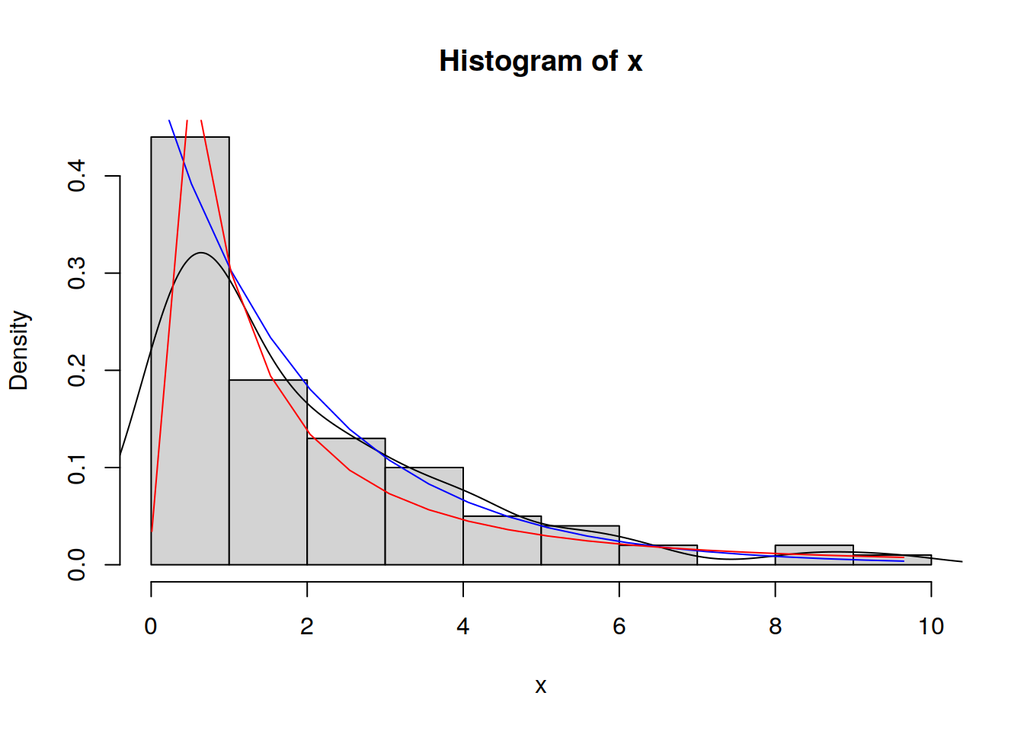

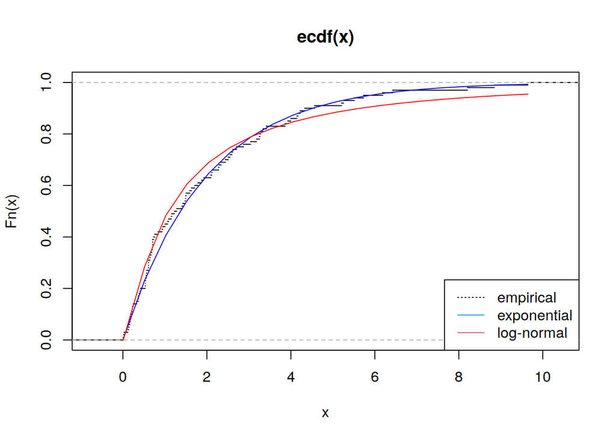

```r
xnew <- seq(min(x), max(x), length.out = 20)
hist(x, probability = T)
lines(density(x))
lines(x = xnew, y = dexp(xnew, rate = fit_exp["mle"]), col = "blue")
lines(xnew, dlnorm(xnew, meanlog = mean(log(x)), sdlog = sd(log(x))), col = "red")

plot(empCDF, pch = ".")
lines(xnew, pexp(xnew, rate = fit_exp["mle"]), col = "blue")
lines(xnew, plnorm(xnew, meanlog = mean(log(x)), sdlog = sd(log(x))), col = "red")
legend("bottomright", legend = c("empirical", "exponential", "log-normal"),
       col = c(1,4,2), lty = c(3,1,1))
```

Test dobrej zhody pri tak malom výbere nemá dosť dôkazov na zamietnutie hypotézy, že dáta pochádzajú z log-normálneho rozdelenia:

```r
ks.test(x, y = pexp, rate = 1/mean(x))
```

```
##
##  One-sample Kolmogorov-Smirnov test
##
## data:  x
## D = 0.089524, p-value = 0.3993
## alternative hypothesis: two-sided
```

```r
ks.test(x, y = plnorm, meanlog = mean(log(x)), sdlog = sd(log(x)))
```

```
##
##  One-sample Kolmogorov-Smirnov test
##
## data:  x
## D = 0.092075, p-value = 0.3647
## alternative hypothesis: two-sided
```

Pri desaťnásobnom rozsahu náhodného výberu zo základného súboru je už záver testu jednoznačne v prospech exponenciálneho rozdelenia.

```r
set.seed(321)
x <- rexp(1000, rate = 1/2)
ks.test(x, y = pexp, rate = 1/mean(x))
```

```
##
##  One-sample Kolmogorov-Smirnov test
##
## data:  x
## D = 0.026521, p-value = 0.4827
## alternative hypothesis: two-sided
```

```r
ks.test(x, y = plnorm, meanlog = mean(log(x)), sdlog = sd(log(x)))
```

```
##
##  One-sample Kolmogorov-Smirnov test
##
## data:  x
## D = 0.068629, p-value = 0.0001622
## alternative hypothesis: two-sided
```

## 4.2 Odporúčaná literatúra

**Knihy**

- Kalina a kol. (2010) - Základy pravdepodobnosti a matematickej štatistiky (online iba kapitola 11, https://cran.r-project.org/doc/contrib/FundamentalsOfProbAndMStatistics-Slovak.pdf)
- Litschmannová (2011) - Úvod do statistiky (http://mi21.vsb.cz/modul/uvod-do-statistiky)
- Litschmannová - Úvod do statistiky (interaktivní učební text) - Řešené příklady
- Markechová a kol. (2011) - Úvod do štatistiky pre pedagógov (http://www.km.fpv.ukf.sk/upload_publikacie/20120130_90405__1.pdf)
- Markechová a kol. (2011) - Štatistické metódy a ich aplikácie (https://www.researchgate.net/profile/Dagmar_Markechova)